# Machine Learning for Physical Activity Evaluation

Andrew Pederson

December 18, 2014

## Load data

```r
TestURL <- "https://d396qusza40orc.cloudfront.net/predmachlearn/pml-testing.csv"
TrainURL <- "https://d396qusza40orc.cloudfront.net/predmachlearn/pml-training.csv"

download.file(TrainURL, destfile="./Training.csv", method="curl")
download.file(TestURL, destfile="./Testing.csv", method="curl")
```

```r
setwd("~/Rfiles/PracticalMachineLearnProject")
TrainingBase <- read.csv("./Training.csv", na.strings=c("","NA","#DIV/0!"))
FinalTesting <- read.csv("./Testing.csv", na.strings=c("","NA","#DIV/0!"))
```

## Clean out near zero and NA variables

Some variables, like the user name and time stamps, are not necessary for our analysis and can be excluded. Others are mostly zero or NA vaules, and thus not likely worthwhile to include as predictors.

```r
library(caret)
nsv <- nearZeroVar(TrainingBase, saveMetrics=TRUE)
na.prop <- function(x) {
      sum(is.na(x))/length(x)
  }

deletevars <- c("X","user_name","raw_timestamp_part_1","raw_timestamp_part_2"
                ,"cvtd_timestamp", "new_window", "num_window",
                rownames(nsv[nsv$zeroVar==TRUE,]),
                names(which(sapply(TrainingBase,na.prop)>0.95)))

TrainingBase <- TrainingBase[,-which(names(TrainingBase) %in% deletevars)]
```

## Split the data into training and test sets

To avoid overfitting our model, we split the “base” training data set 60/40 into new training and testing sets.

```r
library(caret)
set.seed(12345)
trainIndex = createDataPartition(y=TrainingBase$classe, p = 0.60,list=FALSE)
training = TrainingBase[trainIndex,]
testingInit = TrainingBase[-trainIndex,]
```

## Evaluate and select covariates to use as predictors

There are still too many variables to plot efficiently, so we use hierarchical clustering to identify some variables of interest in the training set.

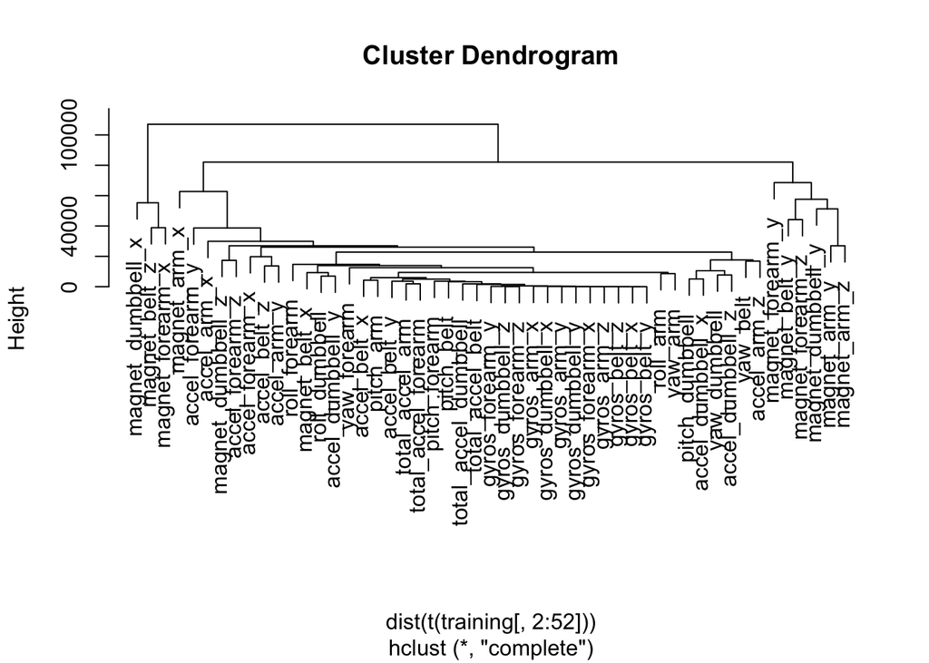

```r
hcluster = hclust(dist(t(training[,2:52])))
plot(hcluster)
```

We can see that the magnetometer and accelerometer variables seem to be important in determining clustering, though it’s not possible to identify any clear relationships by plotting any of those variables. The plot below illustrates how noisy this data is.

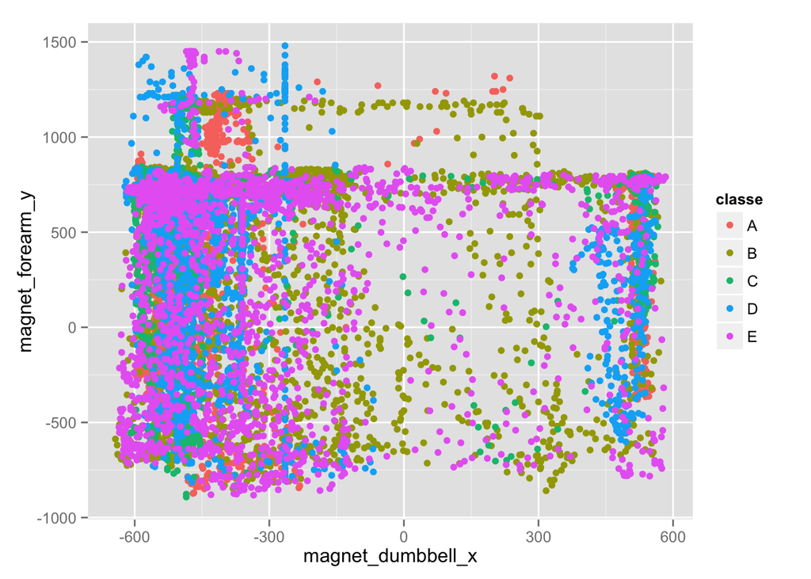

```r
qplot(magnet_dumbbell_x, magnet_forearm_y, colour=classe, data=training)
```

## Fitting the model

Since no clear linear relationships are visible, we decide to apply a tree-based method. An initial tree model built with the “rpart” method applied to the data preprocessed with a principle components analysis yielded less than 40% accuracy, and was not able to detect Classes B or C at all.

```r
Prtrain <- trainControl(method="cv", number=5)
PrcompMod <- train(classe~., data=training, trControl=Prtrain, preProcess="pca", method="rpart")
library(rattle)
```

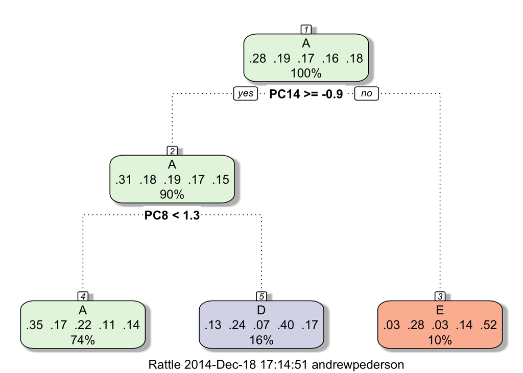

```r
fancyRpartPlot(PrcompMod$finalModel)
```

```r
PRpred <- predict(PrcompMod, newdata=testingInit)
confusionMatrix(PRpred, testingInit$classe)
```

```
## Confusion Matrix and Statistics
##
##           Reference
## Prediction    A    B    C    D    E
##          A 2054 1023 1264  662  796
##          B    0    0    0    0    0
##          C    0    0    0    0    0
##          D  152  288   79  513  213
##          E   26  207   25  111  433
##
## Overall Statistics
##
##                Accuracy : 0.3824
##                  95% CI : (0.3716, 0.3932)
##     No Information Rate : 0.2845
##     P-Value [Acc > NIR] : < 2.2e-16
##
##                   Kappa : 0.1709
##  Mcnemar's Test P-Value : NA
##
## Statistics by Class:
##
##                      Class: A Class: B Class: C Class: D Class: E
## Sensitivity            0.9203   0.0000   0.0000  0.39891  0.30028
## Specificity            0.3329   1.0000   1.0000  0.88841  0.94238
## Pos Pred Value         0.3542      NaN      NaN  0.41205  0.53990
## Neg Pred Value         0.9130   0.8065   0.8256  0.88290  0.85676
## Prevalence             0.2845   0.1935   0.1744  0.16391  0.18379
## Detection Rate         0.2618   0.0000   0.0000  0.06538  0.05519
## Detection Prevalence   0.7391   0.0000   0.0000  0.15868  0.10222
## Balanced Accuracy      0.6266   0.5000   0.5000  0.64366  0.62133
```

```r
set.seed(625)
CV <- trainControl(method="cv",number=3, allowParallel = TRUE)
RFmodel <- train(classe ~ .,data=training,trControl=CV,method="rf", prox=FALSE)
RFmodel$finalModel
```

```
##
## Call:
##  randomForest(x = x, y = y, mtry = param$mtry, proximity = FALSE)
##                Type of random forest: classification
##                      Number of trees: 500
## No. of variables tried at each split: 27
##
##         OOB estimate of  error rate: 0.99%
## Confusion matrix:
##      A    B    C    D    E class.error
## A 3338    6    2    0    2 0.002986858
## B   21 2246   11    0    1 0.014480035
## C    1    8 2032   13    0 0.010710808
## D    0    0   30 1896    4 0.017616580
## E    0    2    6    9 2148 0.007852194
```

## Applying the model to the initial test data set

```r
RFpred <- predict(RFmodel, newdata=testingInit)
confusionMatrix(RFpred, testingInit$classe)
```

```
## Confusion Matrix and Statistics
##
##           Reference
## Prediction    A    B    C    D    E
##          A 2229   10    0    0    0
##          B    3 1502    6    0    1
##          C    0    6 1358   18    3
##          D    0    0    4 1266    5
##          E    0    0    0    2 1433
##
## Overall Statistics
##
##                Accuracy : 0.9926
##                  95% CI : (0.9905, 0.9944)
##     No Information Rate : 0.2845
##     P-Value [Acc > NIR] : < 2.2e-16
##
##                   Kappa : 0.9906
##  Mcnemar's Test P-Value : NA
##
## Statistics by Class:
##
##                      Class: A Class: B Class: C Class: D Class: E
## Sensitivity            0.9987   0.9895   0.9927   0.9844   0.9938
## Specificity            0.9982   0.9984   0.9958   0.9986   0.9997
## Pos Pred Value         0.9955   0.9934   0.9805   0.9929   0.9986
## Neg Pred Value         0.9995   0.9975   0.9985   0.9970   0.9986
## Prevalence             0.2845   0.1935   0.1744   0.1639   0.1838
## Detection Rate         0.2841   0.1914   0.1731   0.1614   0.1826
## Detection Prevalence   0.2854   0.1927   0.1765   0.1625   0.1829
## Balanced Accuracy      0.9984   0.9939   0.9943   0.9915   0.9967
```

Accuracy is over 99% when applied to the testing dataset, and the estimated out of sample error rate is less than 1%.